# Data frames and data import/export

Hugo and Nadia

# Data frame

- Data frame – 2-dimensional table with data (Excel spreadsheet, SQL-table)
- De facto it is standard way of data storage as “observations/variables”:  
  rows are associated with observations, columns – with variables

| Places | N_coord | E_coord | Date | Temp |
| --- | --- | --- | --- | --- |
| MM Faculty | 59.88 | 29.83 | 07.01.2014 | -15 |
| PP Fortress | 59.95 | 30.32 | 15.05.2013 | 17 |
| SPbU main | 59.94 | 30.3 | 22.06.2013 | 22 |
| MM Faculty | 59.88 | 29.83 | 09.01.2014 | -21 |
| … | … | … | … | … |

Data frame inherited properties of matrices (rectangular shape) and lists (variables can have different types).

## Creating data frames

```r
LETTERS
```

```
##  [1] "A" "B" "C" "D" "E" "F" "G" "H" "I" "J" "K" "L" "M" "N" "O" "P" "Q" "R" "S" "T" "U" "V" "W" "X" "Y" "Z"
```

```r
df <- data.frame(x = 1:4, y = LETTERS[1:4], z = c(T, F))
df
```

```
##   x y     z
## 1 1 A  TRUE
## 2 2 B FALSE
## 3 3 C  TRUE
## 4 4 D FALSE
```

Function `str` gives information about the object and types of its variables:

```r
str(df)
```

```
## 'data.frame':    4 obs. of  3 variables:
##  $ x: int  1 2 3 4
##  $ y: Factor w/ 4 levels "A","B","C","D": 1 2 3 4
##  $ z: logi  TRUE FALSE TRUE FALSE
```

## Names

```r
df <- data.frame(x = 1:4, y = LETTERS[1:4], z = c(T, F),
                 row.names = c("Alpha", "Bravo", "Charlie", "Delta"))
df
```

```
##         x y     z
## Alpha   1 A  TRUE
## Bravo   2 B FALSE
## Charlie 3 C  TRUE
## Delta   4 D FALSE
```

```r
row.names(df)
```

```
## [1] "Alpha"   "Bravo"   "Charlie" "Delta"
```

```r
colnames(df)
```

```
## [1] "x" "y" "z"
```

```r
dimnames(df)
```

```
## [[1]]
## [1] "Alpha"   "Bravo"   "Charlie" "Delta"
##
## [[2]]
## [1] "x" "y" "z"
```

## Dimensions

```r
nrow(df); ncol(df)
```

```
## [1] 4
```

```
## [1] 3
```

```r
dim(df)
```

```
## [1] 4 3
```

Important peculiarities:

- `length(df)` returns the number of *columns* (variables), not the overall element number
- `names(df)` also returns only column names

```r
length(df); names(df)
```

```
## [1] 3
```

```
## [1] "x" "y" "z"
```

## Data frame indexing

Indexing works the same way as for matrix:

```r
df[3:4, -1]
```

```
##         y     z
## Charlie C  TRUE
## Delta   D FALSE
```

```r
df[, 1]; df[, 1, drop = FALSE]
```

```
## [1] 1 2 3 4
```

```
##         x
## Alpha   1
## Bravo   2
## Charlie 3
## Delta   4
```

Or for lists:

```r
df$z
```

```
## [1]  TRUE FALSE  TRUE FALSE
```

```r
df[[3]]
```

```
## [1]  TRUE FALSE  TRUE FALSE
```

```r
df[["z"]]
```

```
## [1]  TRUE FALSE  TRUE FALSE
```

## Subsetting using a condition

You can subset of rows/columns of a data frame by either using `subset` function or directly specifying the condition you want to be fulfilled for your subset:

```r
df[df$x > 2, ]
```

```
##         x y     z
## Charlie 3 C  TRUE
## Delta   4 D FALSE
```

```r
subset(df, x > 2)
```

```
##         x y     z
## Charlie 3 C  TRUE
## Delta   4 D FALSE
```

```r
subset(df, x > 2, select = c(x, z))
```

```
##         x     z
## Charlie 3  TRUE
## Delta   4 FALSE
```

## Combining data frames

Functions `rbind`/`cbind` work the same way as for matrices:

```r
rbind(df, data.frame(x = 5:6, y = c("K", "Z"), z = TRUE, row.names = c("Kappa", "Zulu")))
```

```
##         x y     z
## Alpha   1 A  TRUE
## Bravo   2 B FALSE
## Charlie 3 C  TRUE
## Delta   4 D FALSE
## Kappa   5 K  TRUE
## Zulu    6 Z  TRUE
```

```r
cbind(df, data.frame(season = c("Summer", "Autumn", "Winter", "Spring"), temp = c(20, 5, -10, 5)))
```

```
##         x y     z season temp
## Alpha   1 A  TRUE Summer   20
## Bravo   2 B FALSE Autumn    5
## Charlie 3 C  TRUE Winter  -10
## Delta   4 D FALSE Spring    5
```

## Combining data frames: `merge`

```r
df
```

```
##         x y     z
## Alpha   1 A  TRUE
## Bravo   2 B FALSE
## Charlie 3 C  TRUE
## Delta   4 D FALSE
```

Function `merge` allows you to merge data frames by a common variable:

```r
df_salary <- data.frame(x = c(3, 2, 6, 1), salary = c(100, 1000, 300, 500))
merge(df, df_salary, by = "x")
```

```
##   x y     z salary
## 1 1 A  TRUE    500
## 2 2 B FALSE   1000
## 3 3 C  TRUE    100
```

# Importing data

The easiest way to save and load data is using `".RData"` format:

```r
save(df, file="my_data_frame.RData")
load("my_data_frame.RData")
```

You can save multiple objects or even the whole environment in the `.RData` file. But it’s gonna be heavy and not readable by anything else than R.

Usually the data is stored in tables or text/data files, which you will read with `read.*` function.

Main instrument – `read.table` function:

- `file` – name of a file
- `header` – presence or absence of the header (names of columns) in the first row
- `sep` – separator of values
- `dec` – decimal point
- `quote` – symbol denoting quotation marks for characters
- `na.strings` – strings encoding missing values
- `colClasses` – types of columns (to speed up reading or huge dataframes)
- `comment.char` – symbol denoting comments
- `skip` – number of rows to skip from the beginning of the file

Functions `read.csv`, `read.csv2`, `read.delim` и `read.delim2` are essentially spans over `read.table` function with different defaults for parameters.

## Typical pre-processing workflow:

- Importing data into a data frame
- Cleaning the values, checking the types
- Working with strings: names, character variables, factors
- Missing values: indentification, processing
- Manipulating variables: transformation, creation, removal
- Descriptive statistics calculation: split-apply-combine
- Visualisation
- Export

## Cleaning the data, checking the types

- Numeric types can become characters:
  - because of missing values designated with anything else than `NA` `na.strings = c("NA", "Not Available", "Missing")`
  - because of wrong separators or decimal signs  
    `sep = ","`, `dec = "."`
  - because of wrong quotation marks, supplementary text or comments  
    `quote`, `comment.char`, `skip` >- Characters can become factors and the other way round  
    `as.character`, `as.factor`

Very useful functions: * `str` – check types of the variables * `summary` – check summary statistics (mean, median, min and max) * `head` – first 6 rows of a data frame * `tail`– last 6 rows of a data frame

## Processing variables

- Functions `complete.cases` and `na.omit` to get rid of observations with missing values:  
  `df[complete.cases(df), ]` or `na.omit(df)`
- It’s dangerous to replace NA with other values!
- Creating, altering and deleting variables  
  `df$new_var <- <...>`,  
  `df$old_var <- f(df$old_var)`,  
  `df$old_var <- NULL`

## Export

- `write.table`, `write.csv` and `write.csv2` – almost identical to import functions
- If an array is big enough, it;s better to separate the pre-processing step
  - in a separate “.R” file
  - write the preprocessed (“clean”) data in a separate file

## Playing with the dataset tutorial

Please visit [this webpage](http://tinyurl.com/BTM2016-RDatasets) to go on with analysing datasets.

## Hands-on part

**Exercise.** The built-in data set `mtcars` contains information about cars from a 1974 Motor Trend issue. Load the data set (`data(mtcars)`) and try to answer the following:

1. What are the variable names? (Try `names`.)
2. What is the maximum `mpg`? (Try `max`.)
3. Which car has this? (Try `which`.)
4. What are the first 5 cars listed?
5. What are all the values for the Mercedes 450slc (`Merc 450SLC`)? Save it in the file “Merc.dat” with `write.table`.
6. Make a scatterplot of cylinders (`cyl`) vs. miles per gallon (`mpg`). Fit a regression line. Is this a good candidate for linear regression?

## Solution

1. What are the variable names?

```r
data(mtcars) # upload data
names(mtcars)
```

```
##  [1] "mpg"  "cyl"  "disp" "hp"   "drat" "wt"   "qsec" "vs"   "am"   "gear" "carb"
```

2. What is the maximum `mpg`?

```r
max(mtcars$mpg)
```

```
## [1] 33.9
```

3. Which car has this?

```r
row.names(mtcars)[which(mtcars$mpg==33.9)]
```

```
## [1] "Toyota Corolla"
```

```r
# following strings will do the same:
row.names(mtcars)[which.max(mtcars$mpg)]
```

```
## [1] "Toyota Corolla"
```

```r
row.names(mtcars)[which(mtcars$mpg==max(mtcars$mpg))]
```

```
## [1] "Toyota Corolla"
```

4. What are the first 5 cars listed?

```r
row.names(mtcars)[1:5]
```

```
## [1] "Mazda RX4"         "Mazda RX4 Wag"     "Datsun 710"        "Hornet 4 Drive"    "Hornet Sportabout"
```

5. What are all the values for the Mercedes 450slc (`Merc 450SLC`)? Save it in the file “Merc.dat” with `write.table`.

```r
mtcars[row.names(mtcars)=="Merc 450SLC",]
```

```
##              mpg cyl  disp  hp drat   wt qsec vs am gear carb
## Merc 450SLC 15.2   8 275.8 180 3.07 3.78   18  0  0    3    3
```

```r
# Since row.names should be unique, this will do the same:
mtcars["Merc 450SLC",]
```

```
##              mpg cyl  disp  hp drat   wt qsec vs am gear carb
## Merc 450SLC 15.2   8 275.8 180 3.07 3.78   18  0  0    3    3
```

```r
data_to_save <- mtcars[row.names(mtcars)=="Merc 450SLC",]
write.table(data_to_save, file="Merc.dat")
```

6. Make a scatterplot of cylinders (`cyl`) vs. miles per gallon (`mpg`). Fit a regression line. Is this a good candidate for linear regression?

```r
cor(mtcars$cyl,mtcars$mpg)
```

```
## [1] -0.852162
```

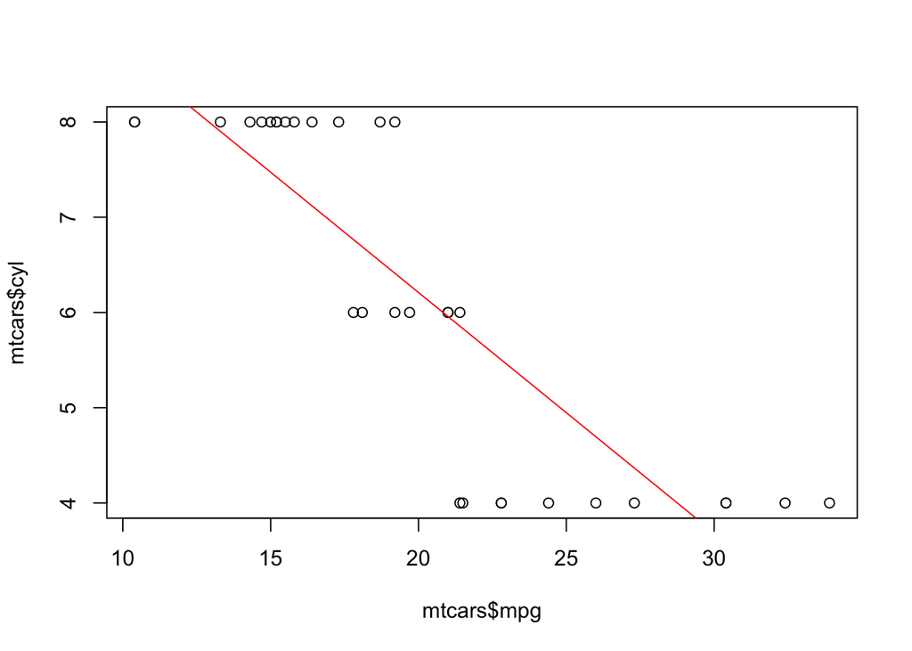

```r
fit <- lm(mtcars$cyl ~ mtcars$mpg)
plot(mtcars$mpg,mtcars$cyl)
abline(fit,col="red")
```

# Acknowledgements

Huge thanks to [Anton Antonov](http://github.com/tonytonov) for his lectures on R on stepik.org.